# Notes on Statistics

# Part II: Modeling

```r
head(cars)
```

```
##   speed dist
## 1     4    2
## 2     4   10
## 3     7    4
## 4     7   22
## 5     8   16
## 6     9   10
```

```r
(n <- nrow(cars))
```

```
## [1] 50
```

```r
x <- cars$speed
y <- cars$dist
```

## Linear Model

Equation: $Y = X \hat{\beta} + \epsilon$

$\left[\begin{array} {r} Y_1 \\ ... \\ Y_N \end{array}\right] = \left[\begin{array} {rrrr} 1 & x_1 & ... & x_{p-1} \\ ... & ... & ... & ... \\ 1 & x_{1,N} & ... & x_{p-1,N} \end{array}\right] \left[\begin{array} {r} \beta_0 \\ \beta_1 \\ ... \\ \beta_{p-1} \end{array}\right] + \left[\begin{array} {r} \epsilon_0 \\ ... \\ \epsilon_N \end{array}\right]$

X: N x p ( rows x columns)

Solution (LSE)

$X^T Y = X^T X \hat{\beta}$

$\hat{\beta} = (X^T X)^{-1} X^T Y$

If $X = QR, Q^TQ=I$, then $R\hat{\beta} = Q^TY$ (back-substitution)

Hat-matrix

$\hat{Y} = H Y$

$\hat{Y} = X \hat{\beta}$

$H = X (X^T X) ^ {-1} X^T$

Mean Square Error

$r = Y - \hat{Y} = (I - H) Y$ $MSE = \frac{1}{N - p} r^Tr$

Weighted LSE, best $C=W^T W$ is the inverse of $Y$ covariance matrix

$\hat{\beta} = (X^T W ^ T W X)^{-1} X^T W^T W Y$

Sample: Cars

```r
X <- cbind(1, x)
head(X)
```

```
##        x
## [1,] 1 4
## [2,] 1 4
## [3,] 1 7
## [4,] 1 7
## [5,] 1 8
## [6,] 1 9
```

```r
X <- model.matrix(~x)
head(X)
```

```
##   (Intercept) x
## 1           1 4
## 2           1 4
## 3           1 7
## 4           1 7
## 5           1 8
## 6           1 9
```

```r
(b <- solve(crossprod(X)) %*% crossprod(X, y))
```

```
##                   [,1]
## (Intercept) -17.579095
## x             3.932409
```

```r
h <- X %*% solve(crossprod(X)) %*% t(X)
dim(h) # Hii is dinstance from mean (centroid) of X
```

```
## [1] 50 50
```

```r
sum(diag(h)) # model d.f.
```

```
## [1] 2
```

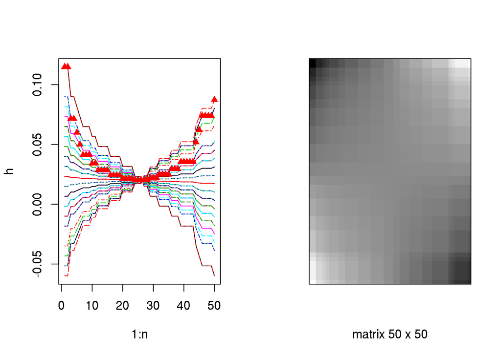

```r
op <- par(mfrow = c(1, 2))
matplot(1:n, h, type="l")
points(diag(h), pch=17, col="red")
draw.matrix(h, g=F)
```

```r
par(op)

#QR optimization
QR <- qr(X)
Q <- qr.Q(QR)
R <- qr.R(QR)
backsolve(R, crossprod(Q, y))
```

```
##            [,1]
## [1,] -17.579095
## [2,]   3.932409
```

```r
solve.qr(QR, y) #QR
```

```
## (Intercept)           x
##  -17.579095    3.932409
```

```r
#solve(R, crossprod(Q,Y))

fitted <- X %*% b # fit existing, or new X
head(fitted, 3)
```

```
##        [,1]
## 1 -1.849460
## 2 -1.849460
## 3  9.947766
```

```r
head(tcrossprod(Q)%*%y, 3) #QR
```

```
##           [,1]
## [1,] -1.849460
## [2,] -1.849460
## [3,]  9.947766
```

```r
residuals <- y - fitted
sum(residuals)
```

```
## [1] 5.471179e-12
```

```r
# standardized residuals
zresiduals <- (residuals - mean(residuals)) / sd(residuals) # scale(residuals)
sresiduals <- residuals / (sd(residuals) * (1 - diag(h)) ^ 2)

(mse <- crossprod(residuals, residuals) / (n - ncol(X)) )
```

```
##          [,1]
## [1,] 236.5317
```

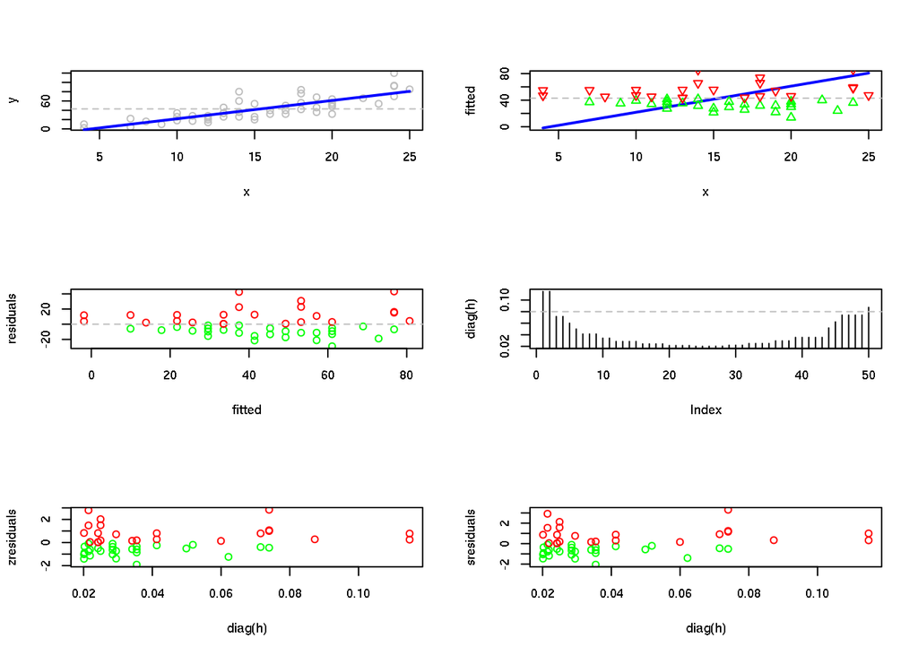

```r
op <- par(mfrow = c(3, 2))
plot(x, y, col="gray")
abline(h=mean(y), lty=2, col="gray")
lines(x, fitted, col="blue", type="l", lwd=2)
plot(x, fitted, col="blue", type="l", lwd=2)
abline(h=mean(y), lty=2, col="gray")
points(x, residuals + mean(y), col=ifelse(residuals > 0, "red", "green"), pch=ifelse(residuals > 0, 6, 2))
plot(fitted, residuals, col=ifelse(residuals > 0, "red", "green"))
abline(h=0, lty=2, col="gray")
plot(diag(h), type="h")
abline(h=2 * mean(diag(h)), lty=2, col="gray")
plot(diag(h), zresiduals, col=ifelse(residuals > 0, "red", "green"), ylab="zresiduals")
plot(diag(h), sresiduals, col=ifelse(residuals > 0, "red", "green"), ylab="sresiduals")
```

```r
par(op)
```

Confounding

```r
# confounding present if different (collinear)
cat("ncol =", ncol(X), "rank =", qr(X)$rank)
```

```
## ncol = 2 rank = 2
```

Model

```r
#formula(dist ~ speed)
fit <- lm(dist ~ speed, data=cars)
summary(fit) # coef(fit)
```

```
##
## Call:
## lm(formula = dist ~ speed, data = cars)
##
## Residuals:
##     Min      1Q  Median      3Q     Max
## -29.069  -9.525  -2.272   9.215  43.201
##
## Coefficients:
##             Estimate Std. Error t value Pr(>|t|)
## (Intercept) -17.5791     6.7584  -2.601   0.0123 *
## speed         3.9324     0.4155   9.464 1.49e-12 ***
## ---
## Signif. codes:  0 '***' 0.001 '**' 0.01 '*' 0.05 '.' 0.1 ' ' 1
##
## Residual standard error: 15.38 on 48 degrees of freedom
## Multiple R-squared:  0.6511, Adjusted R-squared:  0.6438
## F-statistic: 89.57 on 1 and 48 DF,  p-value: 1.49e-12
```

```r
c(fit$rank, fit$qr$rank)
```

```
## [1] 2 2
```

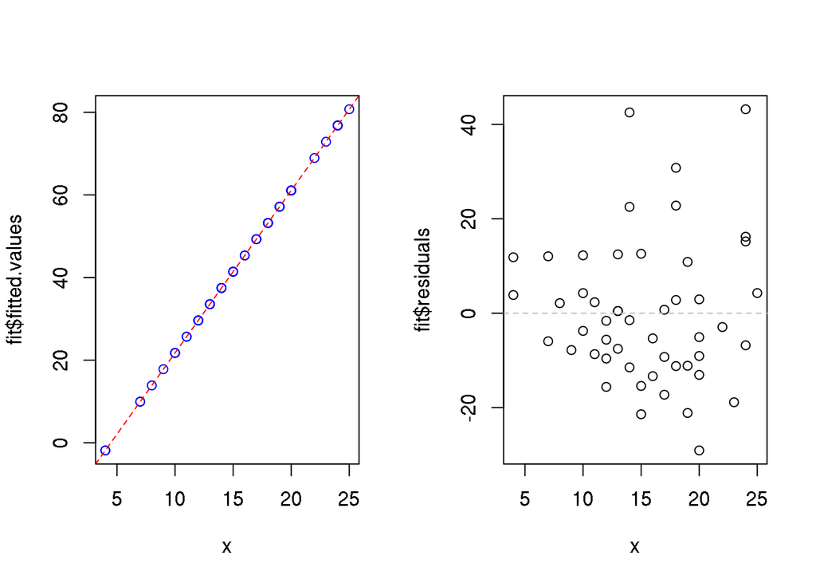

```r
op <- par(mfrow = c(1, 2))
plot(x, fit$fitted.values, col="blue")
abline(a=fit$coefficients[1], b=fit$coefficients[2], lty=2, col="red")
#abline(fit)
plot(x, fit$residuals)
abline(h=0, lty=2, col="gray")
```

```r
par(op)
```

Model diagnostics

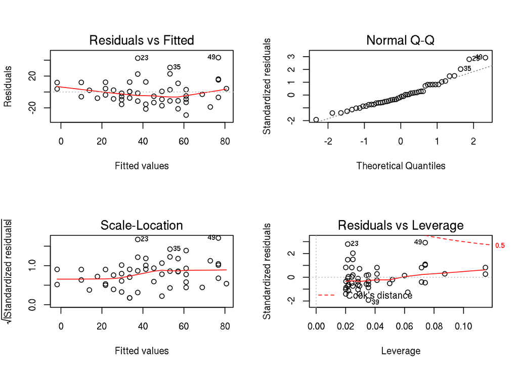

```r
op <- par(mfrow = c(2, 2))
plot(fit)
```

```r
par(op)
```

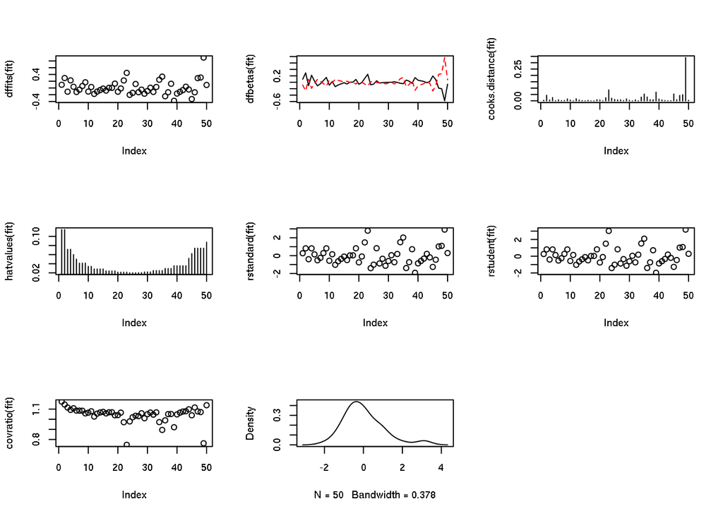

```r
op <- par(mfrow = c(3, 3))
plot(dffits(fit)) # how x affects fitted
matplot(dfbetas(fit), type="l") # how betas change if x is exlcuded (sd relative)
plot(cooks.distance(fit), type="h") # effect of deleting a given observation
plot(hatvalues(fit), type="h") # leverage
plot(rstandard(fit))
plot(rstudent(fit))
plot(covratio(fit))
plot(density(rstudent(fit)), main="")
par(op)
```

```r
head(influence.measures(fit)$infmat, 1)
```

```
##       dfb.1_    dfb.sped      dffit    cov.r      cook.d       hat
## 1 0.09440188 -0.08624563 0.09490289 1.174881 0.004592312 0.1148613
```

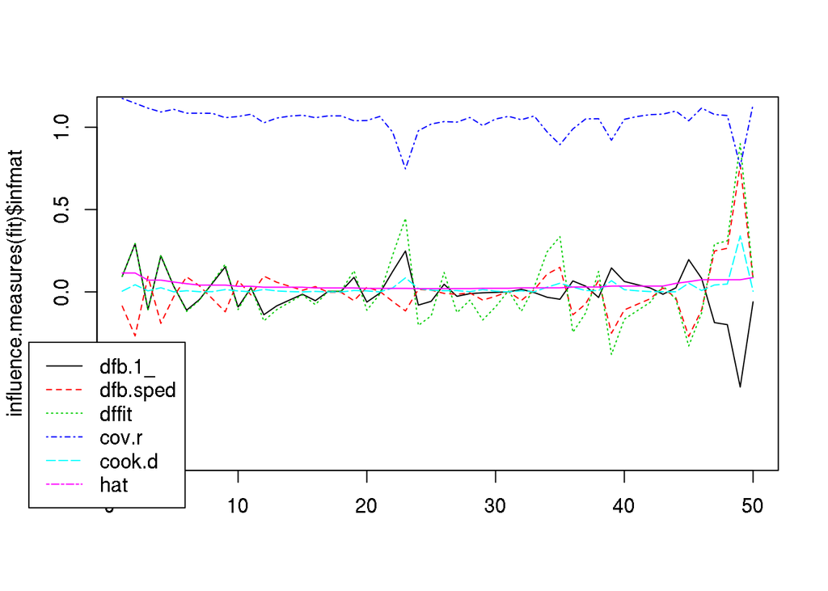

```
##
## No Studentized residuals with Bonferonni p < 0.05
## Largest |rstudent|:
##    rstudent unadjusted p-value Bonferonni p
## 49 3.184993          0.0025707      0.12853
```

```r
cn <- colnames(influence.measures(fit)$infmat)
matplot(influence.measures(fit)$infmat, type="l", ylim=c(-1,1.1)) # summary
legend("bottomleft", legend=cn, lty=1:length(cn), col=1:length(cn), inset=c(-0.1,-0.1), xpd=TRUE)

car::outlierTest(fit)
```

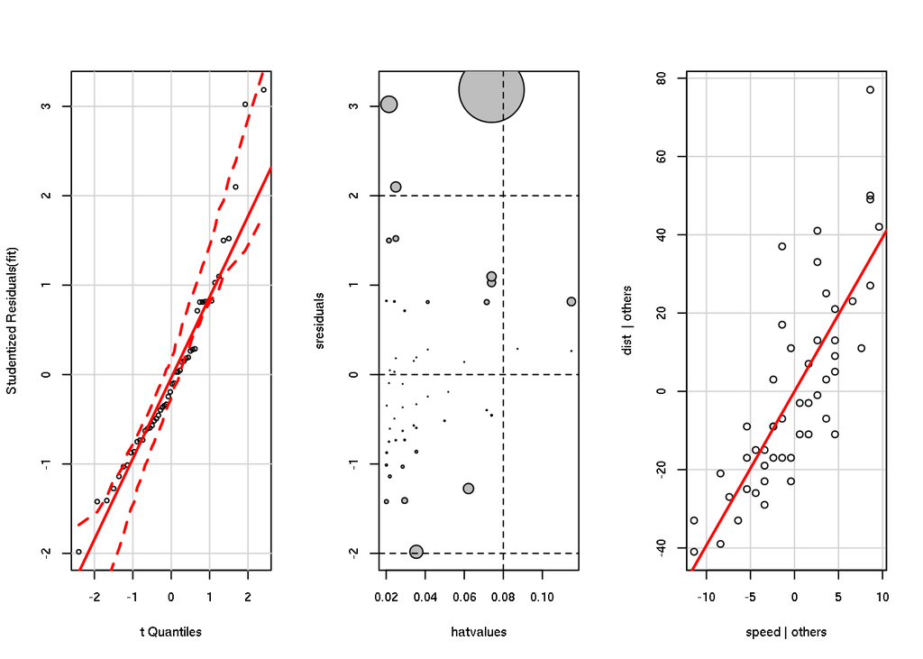

```r
op <- par(mfrow = c(1, 3))
car::qqPlot(fit, simulate=T, labels=row.names(fit))
#influence plot
#influence = leverage (= hatvalues) * discrepency (= dfbetas, or cook's D)
plot(hatvalues(fit), rstudent(fit), type="n", xlab="hatvalues", ylab="sresiduals") # set up
cook <- cooks.distance(fit)
points(hatvalues(fit), rstudent(fit), cex=10 * cook / max(cook), pch=21, bg="gray") # zoom 10
abline(v=2 * mean(diag(h)), h=c(-2,0,2), lty=2) # interesting hatvalues, and sresiduals
# join influence (added-variable (partial-regression) plots) - of no use here, given cars$speed only
car::avPlots(fit)
```

```r
par(op)
```

Prediction

```r
xnew = c(16, 18, 23)
as.vector(cbind(1, xnew) %*% b)
```

```
## [1] 45.33945 53.20426 72.86631
```

```r
predict(fit, list(speed=xnew))
```

```
##        1        2        3
## 45.33945 53.20426 72.86631
```

Confidence

```r
confint(fit)
```

```
##                  2.5 %    97.5 %
## (Intercept) -31.167850 -3.990340
## speed         3.096964  4.767853
```

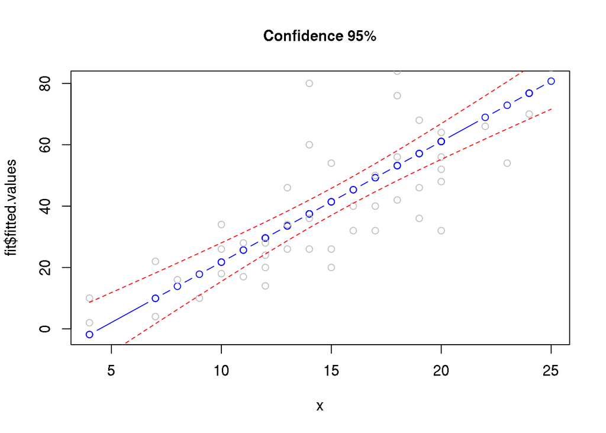

```r
prd <- predict(fit, list(speed=x), interval = c("confidence"), level = 0.95, type="response")
plot(x, fit$fitted.values, col="blue", type="b", main="Confidence 95%")
points(x, y, col="gray")
#lines(x, prd[,2],col="red",lty=2)
#lines(x, prd[,3],col="red",lty=2)
matlines(x, prd[,2:3],col="red",lty=2)
```

Analysis of variance

```r
(a<- anova(fit))
```

```
## Analysis of Variance Table
##
## Response: dist
##           Df Sum Sq Mean Sq F value   Pr(>F)
## speed      1  21186 21185.5  89.567 1.49e-12 ***
## Residuals 48  11354   236.5
## ---
## Signif. codes:  0 '***' 0.001 '**' 0.01 '*' 0.05 '.' 0.1 ' ' 1
```

```r
# speed reduces SS by
a[["Sum Sq"]][1]
```

```
## [1] 21185.46
```

```r
# p-value
1 - pf(a[["F value"]][1], a[["Df"]][1], a[["Df"]][2])
```

```
## [1] 1.489919e-12
```

```r
# autocorrelation between residuals (idependent error terms)?
car::durbinWatsonTest(fit)
```

```
##  lag Autocorrelation D-W Statistic p-value
##    1       0.1604322      1.676225    0.22
##  Alternative hypothesis: rho != 0
```

Comparison

```r
fit2 <- lm(dist ~ speed + I(speed^2), data=cars)
anova(fit2, fit)
```

```
## Analysis of Variance Table
##
## Model 1: dist ~ speed + I(speed^2)
## Model 2: dist ~ speed
##   Res.Df   RSS Df Sum of Sq     F Pr(>F)
## 1     47 10825
## 2     48 11354 -1   -528.81 2.296 0.1364
```

```r
# Akaike's information criterion (AIC) - lack of fit
AIC(fit2, fit) # smaller is better
```

```
##      df      AIC
## fit2  4 418.7721
## fit   3 419.1569
```

```r
speed.factor <- factor(cars$speed)
anova(lm(cars$dist ~ cars$speed + speed.factor))
```

```
## Analysis of Variance Table
##
## Response: cars$dist
##              Df  Sum Sq Mean Sq F value    Pr(>F)
## cars$speed    1 21185.5 21185.5 97.0836 4.558e-11 ***
## speed.factor 17  4588.7   269.9  1.2369    0.2948
## Residuals    31  6764.8   218.2
## ---
## Signif. codes:  0 '***' 0.001 '**' 0.01 '*' 0.05 '.' 0.1 ' ' 1
```

```r
#http://www.statmethods.net/stats/rdiagnostics.html
car::vif(fit2)
```

```
##      speed I(speed^2)
##   24.61489   24.61489
```

```r
sqrt(car::vif(fit2)) > 2 # multi-collinear
```

```
##      speed I(speed^2)
##       TRUE       TRUE
```

```r
car::ncvTest(fit) #non-constant error variance test
```

```
## Non-constant Variance Score Test
## Variance formula: ~ fitted.values
## Chisquare = 4.650233    Df = 1     p = 0.03104933
```

```r
#car::spreadLevelPlot(fit)
```

## Estimation Errors

Model std. errors

```r
summary(fit)$coe[,2]
```

```
## (Intercept)       speed
##   6.7584402   0.4155128
```

Standard error of an estimate is the standard deviation of the sampling distribution of an estimate

```r
b <- replicate(1000, {
  index <- sample(n, 30)
  scars <- cars[index,]
  x <- scars$speed
  y <- scars$dist
  b <- lm(y ~ x)$coef
  b
})
b <- t(b)
head(b, 1)
```

```
##      (Intercept)        x
## [1,]   -23.31326 4.359004
```

```r
apply(b, 2, sd)
```

```
## (Intercept)           x
##   4.9300887   0.3580432
```

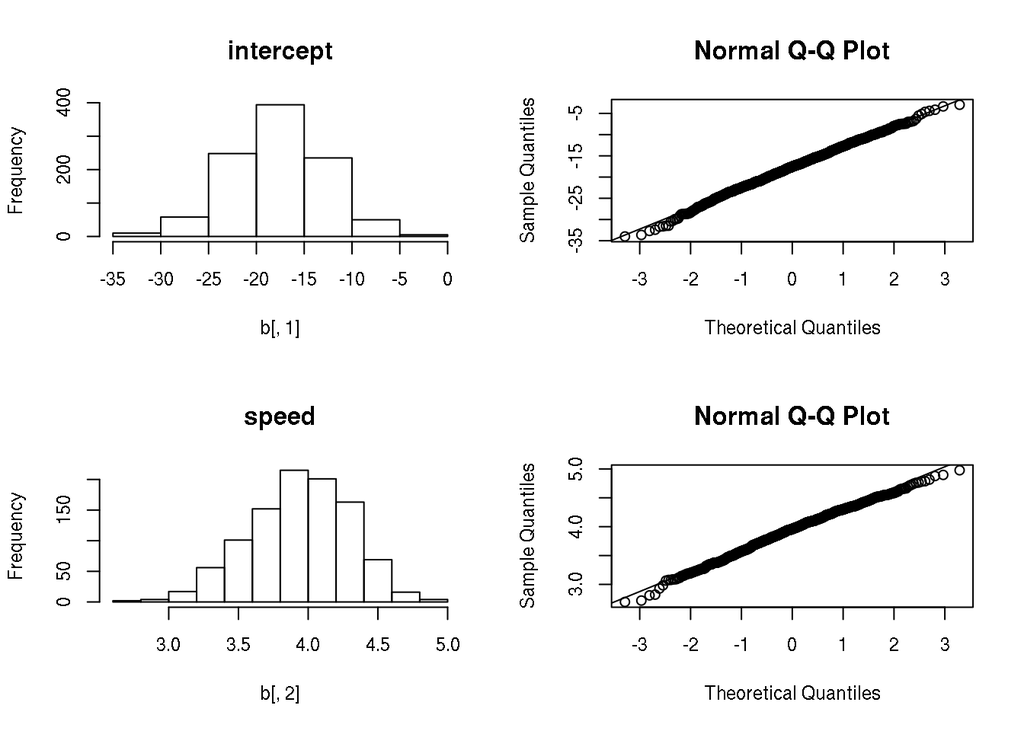

```r
op <- par(mfrow = c(2, 2))
hist(b[,1], main="intercept")
qqnorm(b[,1])
qqline(b[,1])
hist(b[,2], main="speed")
qqnorm(b[,2])
qqline(b[,2])
```

```r
par(op)
```

Correlation of estimates

```r
cor(b[,1], b[,2])
```

```
## [1] -0.9430741
```

Exact variance of estimates:

$\mbox{var}(\mathbf{AY}) = \mathbf{A}\mbox{var}(\mathbf{Y}) \mathbf{A}^\top$

$\mbox{var}(\boldsymbol{\hat{\beta}}) = \sigma^2\mathbf{(X^\top X)^{-1}}$

$\mathbf{r}\equiv\boldsymbol{\hat{\varepsilon}} = \mathbf{Y}-\mathbf{X}\boldsymbol{\hat{\beta}}$

$\Sigma = s^2 \equiv \hat{\sigma}^2 = \frac{1}{N-p}\mathbf{r}^\top\mathbf{r} = \frac{1}{N-p}\sum_{i=1}^N r_i^2$

```r
p <- ncol(X)
residuals <- y - fitted # r
XtXinv <- solve(crossprod(X))
s <- sqrt(sum(residuals^2) / (n - p)) # rss = sum(residuals^2) = crossprod(residuals)
s
```

```
## [1] 15.37959
```

```r
sqrt(crossprod(residuals) / (n - p)) #same s
```

```
##          [,1]
## [1,] 15.37959
```

```r
(ses <- sqrt(diag(XtXinv)) * s) # same std. errors as lm
```

```
## (Intercept)           x
##   6.7584402   0.4155128
```

QR

```r
df <- length(y) - QR$rank
sigma2 <- sum(residuals^2)/df
beta.var <- sigma2 * chol2inv(qr.R(QR))
sqrt(diag(beta.var))
```

```
## [1] 6.7584402 0.4155128
```

t-test

```r
(tstat <- summary(fit)$coe[,1] / summary(fit)$coe[,2])
```

```
## (Intercept)       speed
##   -2.601058    9.463990
```

```r
2 * (1 - pt(abs(tstat), n - 2))
```

```
##  (Intercept)        speed
## 1.231882e-02 1.489919e-12
```

## Models

Let fake some hypothetical data, cars with wonder friction (0 control) and speed class:

```r
n <- nrow(cars)
wcars <- cars
wcars[["odist"]] <- cars$dist # remeber original speed
# wunder friction 1, makes stop distance shorter
wcars[["fric"]] <- as.factor(rep(paste(sep="", "f", 0:1), length.out = n))
index.f1 <- wcars$fric == 'f1'
wcars[index.f1, "dist"] <- round(wcars[index.f1, "dist"] - 0.3 * wcars[index.f1, "dist"])
# speed class: very slow, slow, fast, very fast
mu <- mean(wcars$speed)
ss <- sd(wcars$speed)
wcars[wcars$speed < (mu - ss), "sclass"] <- "VS"
wcars[(wcars$speed >= (mu - ss)) & (wcars$speed < mu), "sclass"] <- "S"
wcars[(wcars$speed >= mu)  & (wcars$speed < (mu + ss)), "sclass"] <- "F"
wcars[wcars$speed >= (mu + ss), "sclass"] <- "VF"
wcars$sclass <- factor(wcars$sclass, levels=c("VS", "S", "F", "VF"))
wcars$group <- factor(paste0(wcars$fric, "." , wcars$sclass))
head(wcars)
```

```
##   speed dist odist fric sclass group
## 1     4    2     2   f0     VS f0.VS
## 2     4    7    10   f1     VS f1.VS
## 3     7    4     4   f0     VS f0.VS
## 4     7   15    22   f1     VS f1.VS
## 5     8   16    16   f0     VS f0.VS
## 6     9    7    10   f1     VS f1.VS
```

```r
tail(wcars)
```

```
##    speed dist odist fric sclass group
## 45    23   54    54   f0     VF f0.VF
## 46    24   49    70   f1     VF f1.VF
## 47    24   92    92   f0     VF f0.VF
## 48    24   65    93   f1     VF f1.VF
## 49    24  120   120   f0     VF f0.VF
## 50    25   60    85   f1     VF f1.VF
```

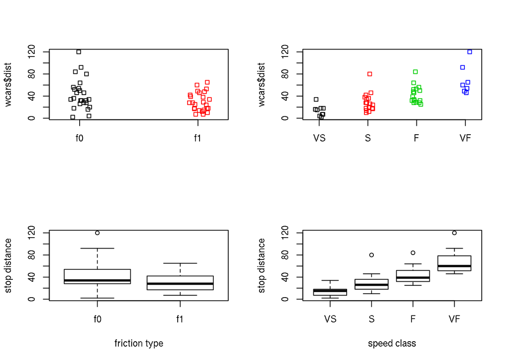

```r
op <- par(mfrow = c(2, 2))
stripchart(wcars$dist ~ wcars$fric, data=wcars, vertical=TRUE, method="jitter", col=wcars$fric)
stripchart(wcars$dist ~ wcars$sclass, data=wcars, vertical=TRUE, method="jitter", col=1:length(levels(wcars$sclass)))
boxplot(wcars$dist ~ wcars$fric, ylab="stop distance", xlab="friction type")
boxplot(wcars$dist ~ wcars$sclass, ylab="stop distance", xlab="speed class")
```

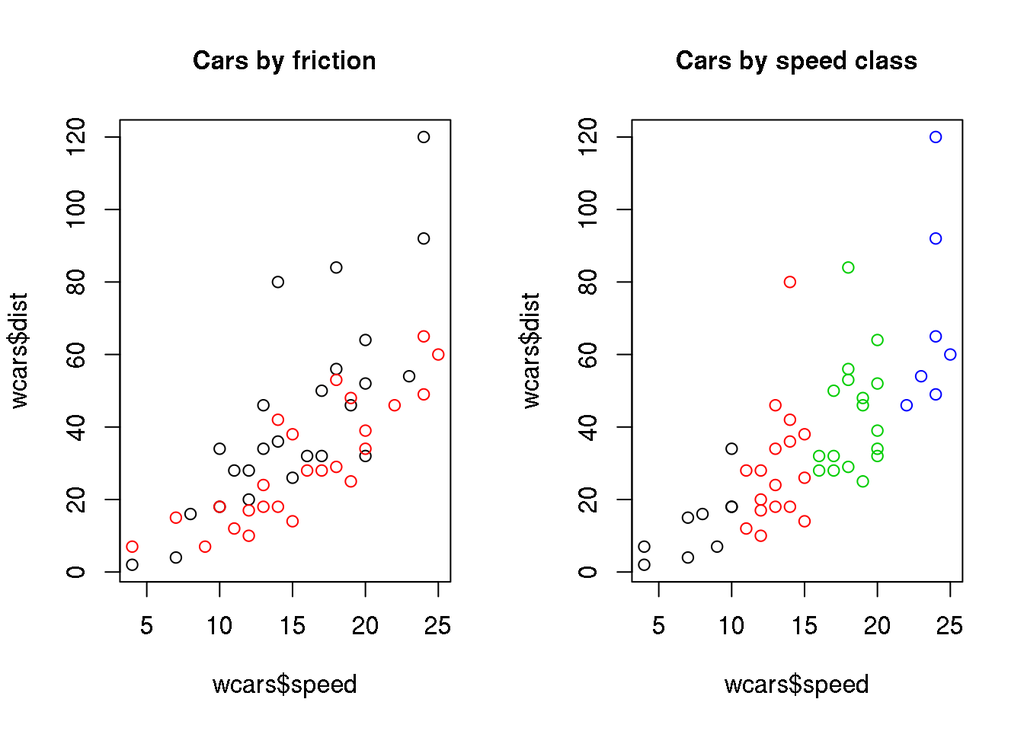

```r
par(op)
op <- par(mfrow = c(1, 2))
plot(wcars$speed, wcars$dist, col=wcars$fric, main="Cars by friction")
plot(wcars$speed, wcars$dist, col=wcars$sclass, main="Cars by speed class")
```

```r
par(op)
```

1. Single factor parameters (one parameter per factor level - 1)

```r
model <- model.matrix(~ fric, data=wcars) # relevel if needed
head(model)
```

```
##   (Intercept) fricf1
## 1           1      0
## 2           1      1
## 3           1      0
## 4           1      1
## 5           1      0
## 6           1      1
```

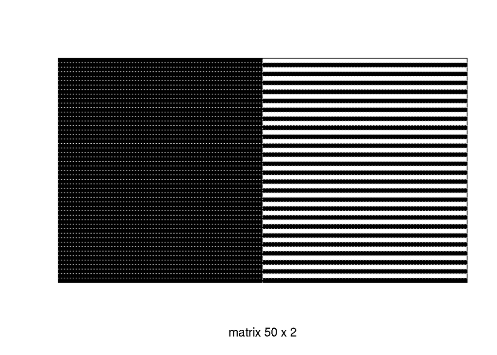

```r
draw.matrix(model) # custom function based on image
```

```r
# changing reference level
levels(wcars$fric)
```

```
## [1] "f0" "f1"
```

```r
(c <- contrasts(wcars$fric))
```

```
##    f1
## f0  0
## f1  1
```

```r
contrasts(wcars$fric) <- contr.treatment(levels(wcars$fric), base=2)
contrasts(wcars$fric)
```

```
##    f0
## f0  1
## f1  0
```

```r
contrasts(wcars$fric) <- c # reset back
contrasts(wcars$fric)
```

```
##    f1
## f0  0
## f1  1
```

```r
cat("ncol =", ncol(model ), "rank =", qr(model )$rank) # confounding if different
```

```
## ncol = 2 rank = 2
```

```r
fit <- lm(dist ~ fric, data=wcars)
summary(fit)$coef
```

```
##             Estimate Std. Error   t value     Pr(>|t|)
## (Intercept)    43.44   4.608391  9.426284 1.689730e-12
## fricf1        -13.68   6.517249 -2.099045 4.109732e-02
```

```r
anova(fit) # one way anova
```

```
## Analysis of Variance Table
##
## Response: dist
##           Df  Sum Sq Mean Sq F value Pr(>F)
## fric       1  2339.3 2339.28   4.406 0.0411 *
## Residuals 48 25484.7  530.93
## ---
## Signif. codes:  0 '***' 0.001 '**' 0.01 '*' 0.05 '.' 0.1 ' ' 1
```

```r
s <- split(wcars$dist, wcars$fric)
mean(s[["f0"]]) # fit$coef[1]
```

```
## [1] 43.44
```

```r
mean(s[["f0"]]) - mean(s[["f1"]]) # fit$coef[2]
```

```
## [1] 13.68
```

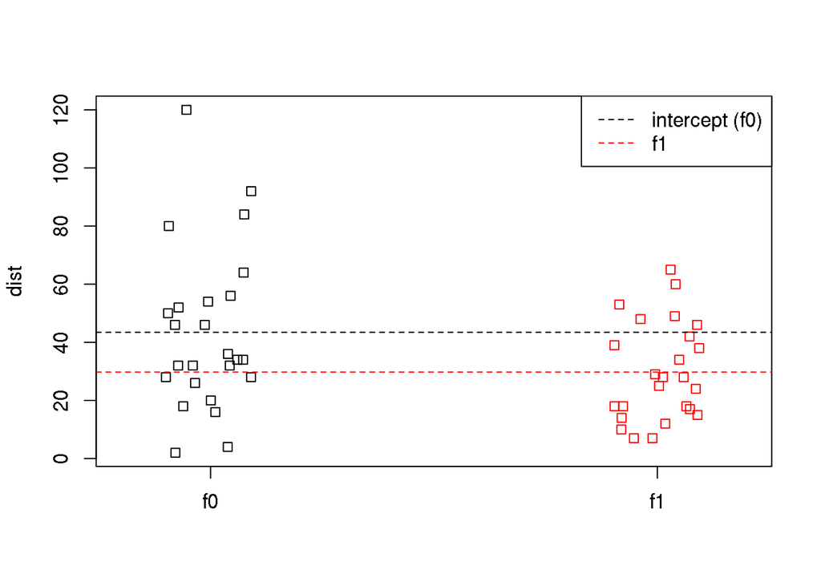

```r
stripchart(dist ~ fric, data=wcars, vertical=TRUE, method="jitter", col=c(1,2))
abline(h=c(fit$coef[1], fit$coef[1] + fit$coef[2]), col=c("black", "red"), lty=2)
legend("topright", legend=c("intercept (f0)", "f1"), col=c(1,2), lty=2)
```

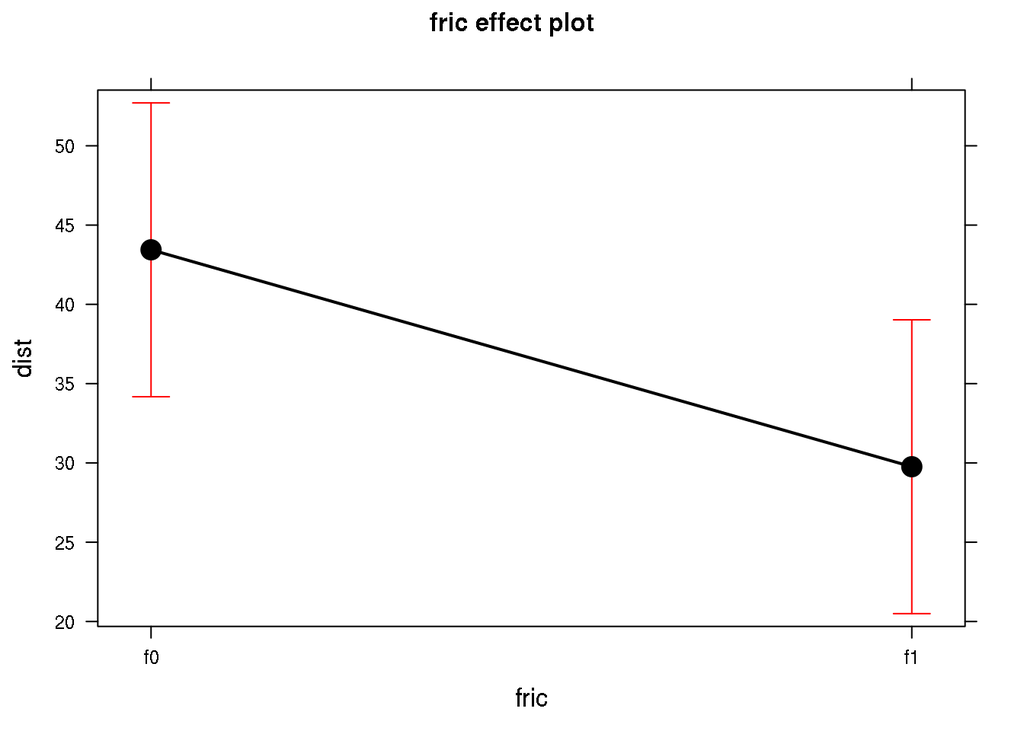

```r
plot(effects::allEffects(fit), multiline=TRUE)
```

```r
t.test(s[["f1"]], s[["f0"]], var.equal=TRUE)$statistic # same as from lm
```

```
##         t
## -2.099045
```

2. Combined factors

```r
model <- model.matrix(~ fric + sclass, data=wcars)
head(model)
```

```
##   (Intercept) fricf1 sclassS sclassF sclassVF
## 1           1      0       0       0        0
## 2           1      1       0       0        0
## 3           1      0       0       0        0
## 4           1      1       0       0        0
## 5           1      0       0       0        0
## 6           1      1       0       0        0
```

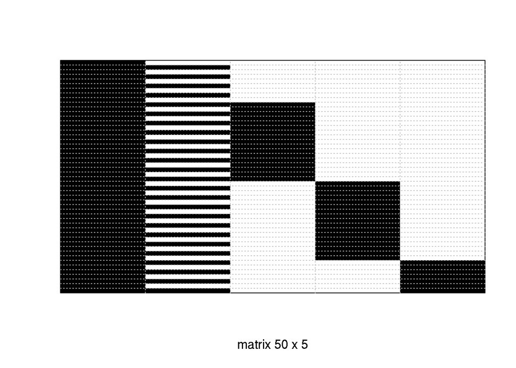

```r
draw.matrix(model)
```

```r
contrasts(wcars$sclass)
```

```
##    S F VF
## VS 0 0  0
## S  1 0  0
## F  0 1  0
## VF 0 0  1
```

```r
fit <- lm(dist ~ fric + sclass, data=wcars)
summary(fit)$coef
```

```
##              Estimate Std. Error   t value     Pr(>|t|)
## (Intercept)  20.31878   5.512459  3.685975 6.102235e-04
## fricf1      -15.46726   4.390903 -3.522570 9.931837e-04
## sclassS      16.75212   6.386636  2.622996 1.185526e-02
## sclassF      30.01875   6.376763  4.707522 2.419541e-05
## sclassVF     57.94822   7.814246  7.415715 2.474366e-09
```

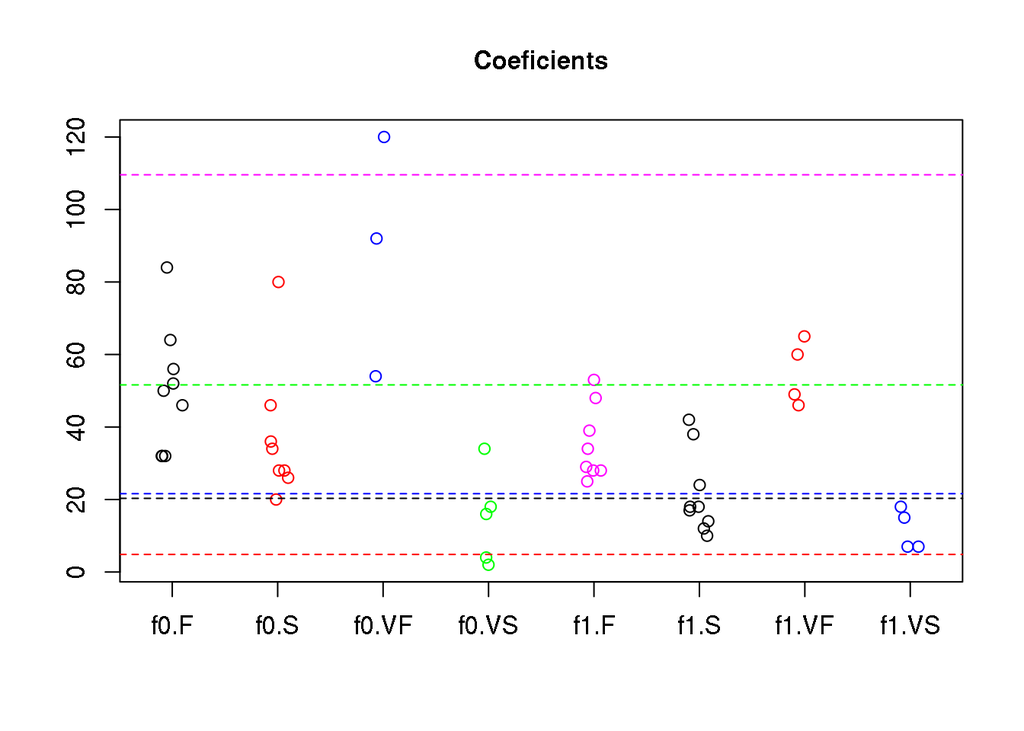

```r
cc <- c("black", "red", "blue", "green", "magenta")
stripchart(split(wcars$dist, wcars$group),
           vertical=TRUE, pch=1, method="jitter", col=cc, main="Coeficients")
abline(h=c(fit$coef[1],
           fit$coef[1] + fit$coef[2],
           fit$coef[1] + fit$coef[2] + fit$coef[3],
           fit$coef[1] + fit$coef[2] + fit$coef[3] + fit$coef[4],
           fit$coef[1] + fit$coef[2] + fit$coef[3] + fit$coef[4] + fit$coef[5]),
       col=cc, lty=2)
```

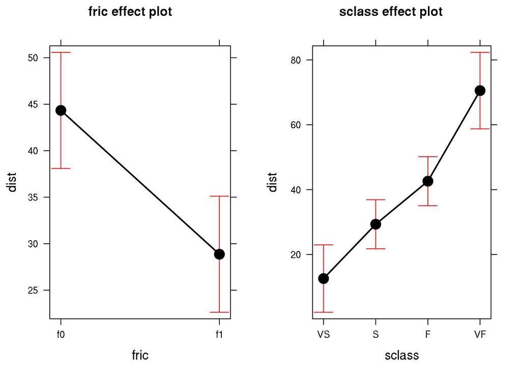

```r
plot(effects::allEffects(fit), multiline=TRUE)
```

```r
summary(effects::allEffects(fit))
```

```
##  model: dist ~ fric + sclass
##
##  fric effect
## fric
##       f0       f1
## 44.33363 28.86637
##
##  Lower 95 Percent Confidence Limits
## fric
##       f0       f1
## 38.09180 22.62453
##
##  Upper 95 Percent Confidence Limits
## fric
##       f0       f1
## 50.57547 35.10820
##
##  sclass effect
## sclass
##       VS        S        F       VF
## 12.58515 29.33727 42.60390 70.53338
##
##  Lower 95 Percent Confidence Limits
## sclass
##        VS         S         F        VF
##  2.189898 21.777591 35.044223 58.742505
##
##  Upper 95 Percent Confidence Limits
## sclass
##       VS        S        F       VF
## 22.98041 36.89695 50.16359 82.32425
```

Coeficients are weighted means of the groups (weighted by group size)

3. Factor interaction

```r
# ~ wcars$fric + wcars$sclass + wcars$fric : wcars$sclass
model <- model.matrix(~ fric * sclass, data=wcars)
colnames(model)
```

```
## [1] "(Intercept)"     "fricf1"          "sclassS"         "sclassF"
## [5] "sclassVF"        "fricf1:sclassS"  "fricf1:sclassF"  "fricf1:sclassVF"
```

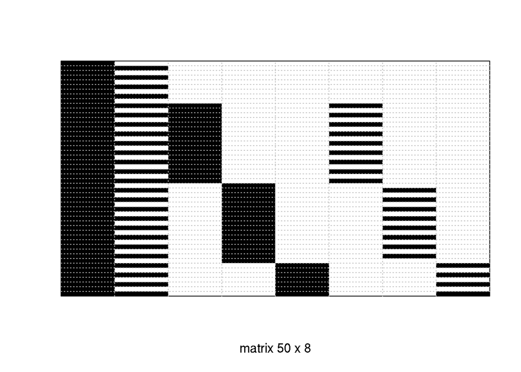

```r
draw.matrix(model)
```

```r
cat("ncol =", ncol(model ), "rank =", qr(model )$rank) # confounding if different
```

```
## ncol = 8 rank = 8
```

```r
fit <- lm(dist ~ fric * sclass, data=wcars)
summary(fit)$coef
```

```
##                  Estimate Std. Error    t value     Pr(>|t|)
## (Intercept)      14.80000   6.847834  2.1612673 3.642356e-02
## fricf1           -3.05000  10.271751 -0.2969309 7.679829e-01
## sclassS          22.45000   8.729310  2.5717955 1.374593e-02
## sclassF          34.97778   8.540750  4.0953991 1.877630e-04
## sclassVF         73.86667  11.182466  6.6055793 5.343055e-08
## fricf1:sclassS  -12.75556  12.683393 -1.0056895 3.203241e-01
## fricf1:sclassF  -11.22778  12.683393 -0.8852345 3.810704e-01
## fricf1:sclassVF -30.61667  15.565334 -1.9669778 5.581513e-02
```

```r
anova(fit) # two way anova
```

```
## Analysis of Variance Table
##
## Response: dist
##             Df  Sum Sq Mean Sq F value    Pr(>F)
## fric         1  2339.3  2339.3  9.9771  0.002935 **
## sclass       3 14720.3  4906.8 20.9276 1.899e-08 ***
## fric:sclass  3   916.9   305.6  1.3036  0.285875
## Residuals   42  9847.5   234.5
## ---
## Signif. codes:  0 '***' 0.001 '**' 0.01 '*' 0.05 '.' 0.1 ' ' 1
```

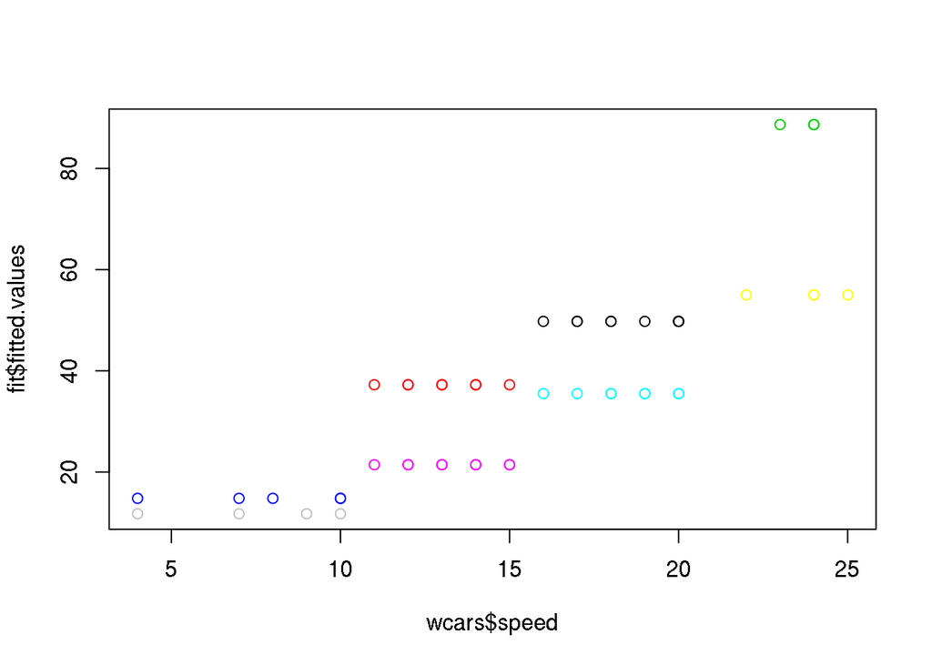

```r
plot(wcars$speed, fit$fitted.values, col=wcars$group)
```

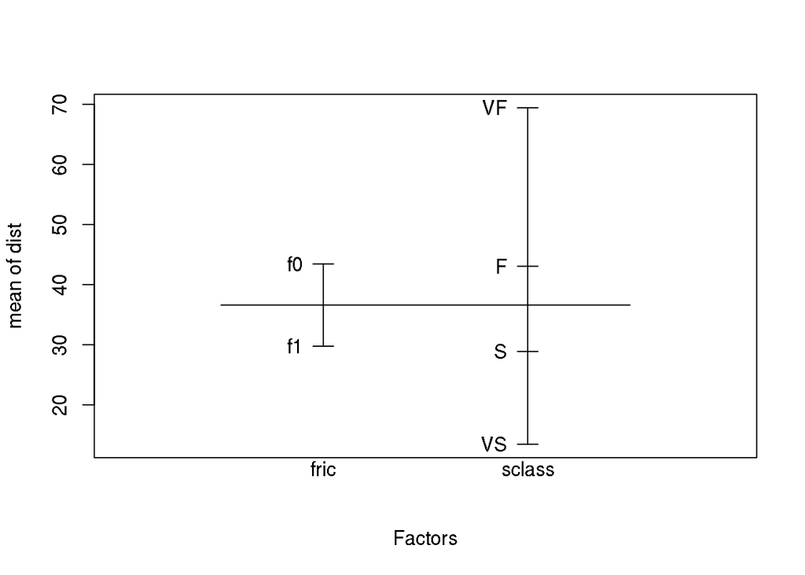

```r
plot.design(dist ~ fric * sclass, data=wcars)
```

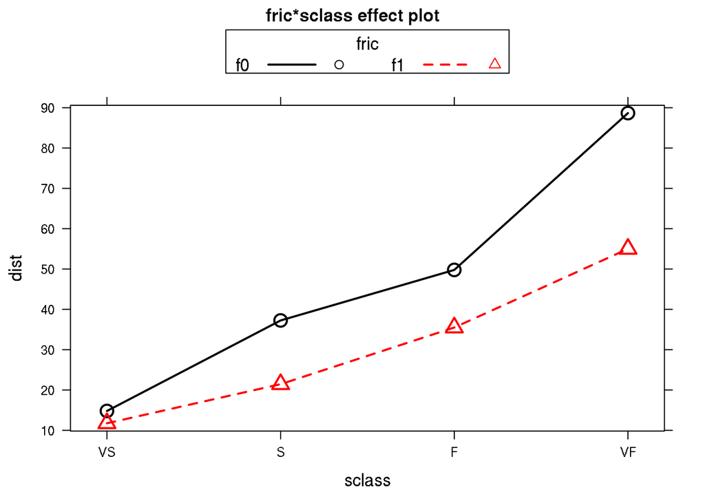

```r
plot(effects::allEffects(fit), multiline=TRUE)
```

Quasi-standard errors

```r
fit$contrasts
```

```
## $fric
##    f1
## f0  0
## f1  1
##
## $sclass
## [1] "contr.treatment"
```

```r
library(qvcalc)
qvcalc(fit, "sclass")
```

```
##    estimate       SE  quasiSE quasiVar
## VS  0.00000  0.00000 6.847834 46.89283
## S  22.45000  8.72931 5.413688 29.30802
## F  34.97778  8.54075 5.104074 26.05157
## VF 73.86667 11.18247 8.840516 78.15472
```

No intercept

```r
model <- model.matrix(~ 0 + group, data=wcars)
head(model)
```

```
##   groupf0.F groupf0.S groupf0.VF groupf0.VS groupf1.F groupf1.S groupf1.VF
## 1         0         0          0          1         0         0          0
## 2         0         0          0          0         0         0          0
## 3         0         0          0          1         0         0          0
## 4         0         0          0          0         0         0          0
## 5         0         0          0          1         0         0          0
## 6         0         0          0          0         0         0          0
##   groupf1.VS
## 1          0
## 2          1
## 3          0
## 4          1
## 5          0
## 6          1
```

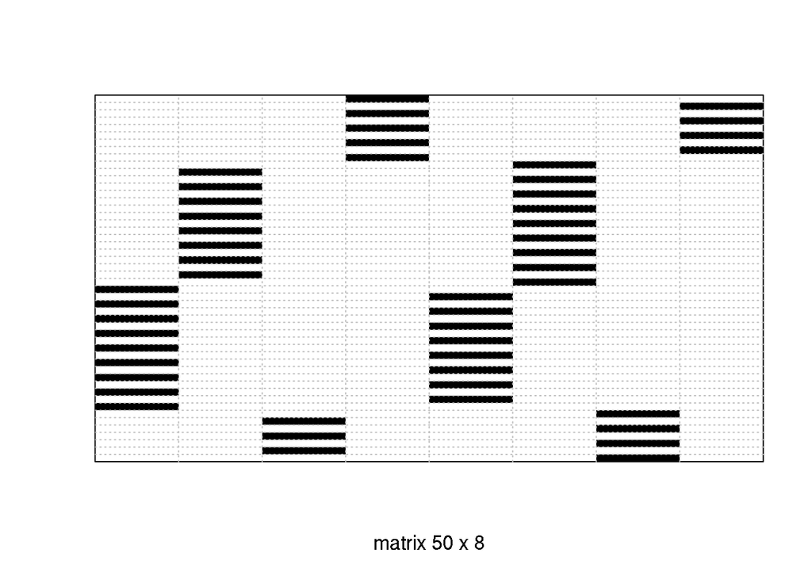

```r
draw.matrix(model)
```

```r
fit <- lm(dist ~ 0 + group, data=wcars)
summary(fit)$coef
```

```
##            Estimate Std. Error   t value     Pr(>|t|)
## groupf0.F  49.77778   5.104074  9.752558 2.357848e-12
## groupf0.S  37.25000   5.413688  6.880707 2.153318e-08
## groupf0.VF 88.66667   8.840516 10.029581 1.027234e-12
## groupf0.VS 14.80000   6.847834  2.161267 3.642356e-02
## groupf1.F  35.50000   5.413688  6.557452 6.265360e-08
## groupf1.S  21.44444   5.104074  4.201437 1.352746e-04
## groupf1.VF 55.00000   7.656111  7.183804 7.944747e-09
## groupf1.VS 11.75000   7.656111  1.534722 1.323517e-01
```

```r
sapply(split(wcars$dist, wcars$group), mean)
```

```
##     f0.F     f0.S    f0.VF    f0.VS     f1.F     f1.S    f1.VF    f1.VS
## 49.77778 37.25000 88.66667 14.80000 35.50000 21.44444 55.00000 11.75000
```

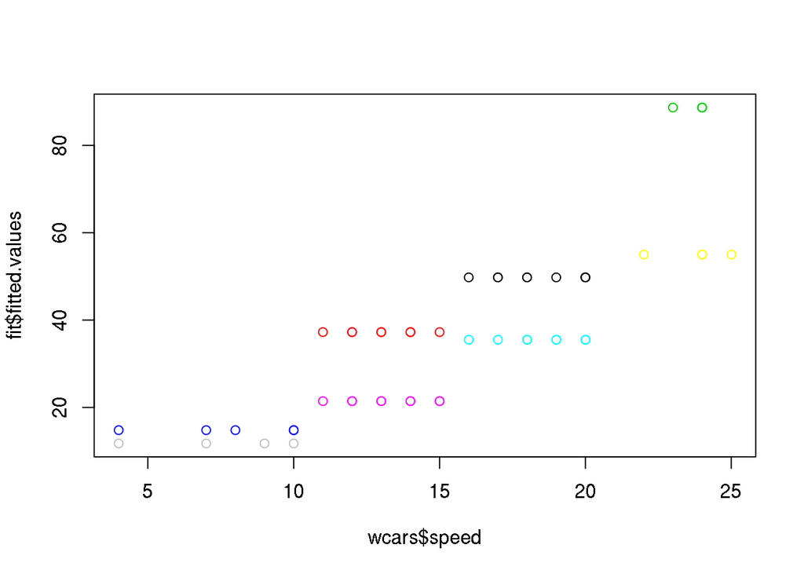

```r
plot(wcars$speed, fit$fitted.values, col=wcars$group)
```

```r
# no anova
```

4. Numeric parameters

```r
# ~ wcars$speed + wcars$fric + wcars$speed : wcars$fric
model <- model.matrix(~ speed * fric, data=wcars)
colnames(model)
```

```
## [1] "(Intercept)"  "speed"        "fricf1"       "speed:fricf1"
```

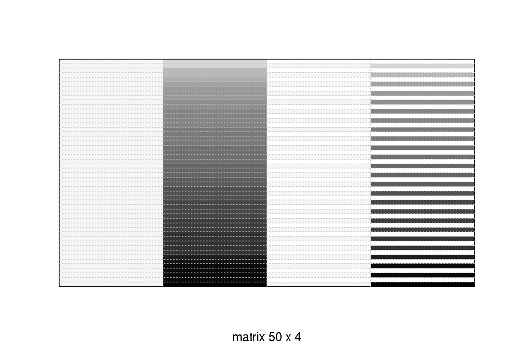

```r
draw.matrix(model)
```

```r
cat("ncol =", ncol(model ), "rank =", qr(model )$rank) # confounding if different
```

```
## ncol = 4 rank = 4
```

```r
fit <- lm(dist ~ speed * fric, data=wcars)
summary(fit)$coef
```

```
##                Estimate Std. Error    t value     Pr(>|t|)
## (Intercept)  -18.618089  8.7820066 -2.1200267 3.942924e-02
## speed          4.093541  0.5481479  7.4679509 1.818771e-09
## fricf1         6.638153 12.4944734  0.5312871 5.977761e-01
## speed:fricf1  -1.424748  0.7683716 -1.8542428 7.012205e-02
```

```r
anova(fit) # ancova - analysis of covariance
```

```
## Analysis of Variance Table
##
## Response: dist
##            Df  Sum Sq Mean Sq F value    Pr(>F)
## speed       1 14932.5 14932.5 74.0256 3.871e-11 ***
## fric        1  2918.8  2918.8 14.4694 0.0004185 ***
## speed:fric  1   693.6   693.6  3.4382 0.0701221 .
## Residuals  46  9279.2   201.7
## ---
## Signif. codes:  0 '***' 0.001 '**' 0.01 '*' 0.05 '.' 0.1 ' ' 1
```

Two lines

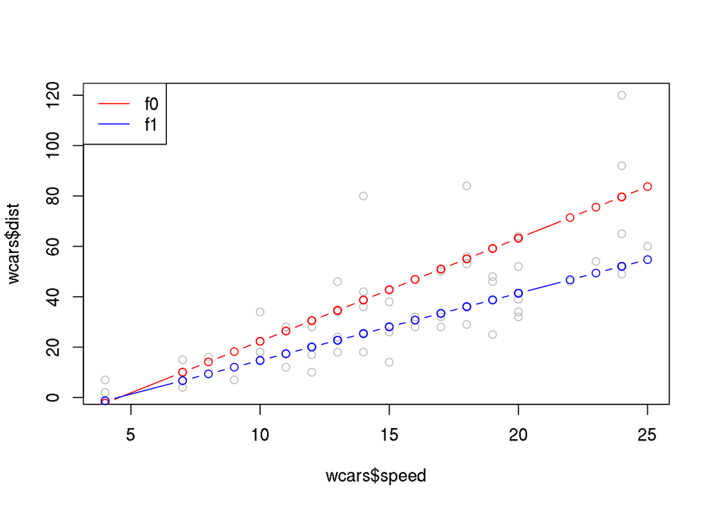

```r
b <- fit$coef
y0 <- b["(Intercept)"] + b["speed"] * wcars$speed
y1 <- (b["(Intercept)"] + b["fricf1"]) + (b["speed"] + b["speed:fricf1"]) * wcars$speed

plot(wcars$speed, wcars$dist, col="gray")
lines(wcars$speed, y0, type="b", col="red")
lines(wcars$speed, y1, type="b", col="blue")
legend("topleft", legend=c("f0", "f1"), col=c("red", "blue"), lty=1)
```

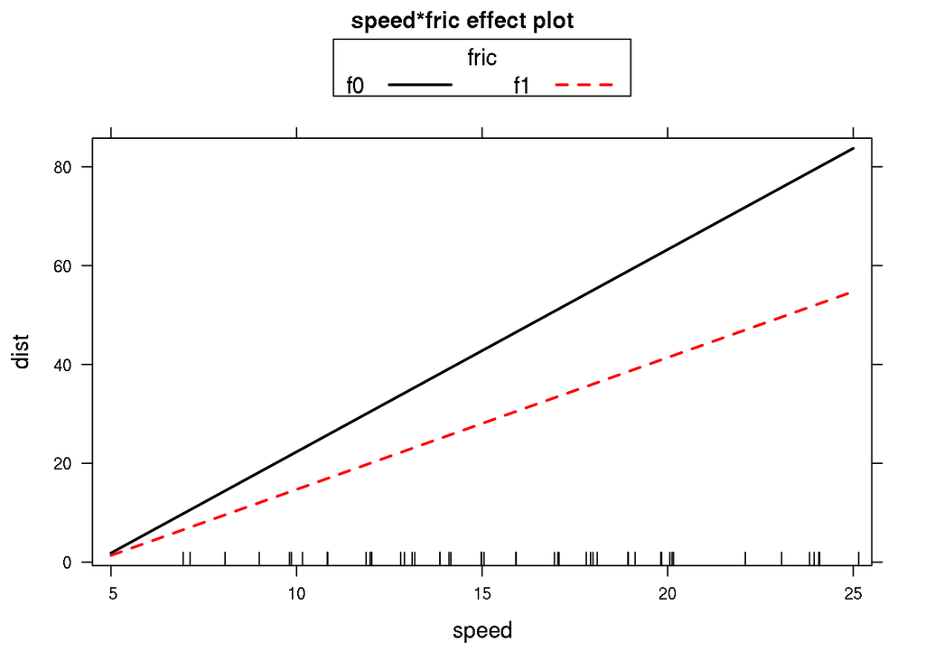

```r
plot(effects::allEffects(fit), multiline=TRUE)
```

Model simplification

```r
step(fit)
```

```
## Start:  AIC=269.18
## dist ~ speed * fric
##
##              Df Sum of Sq    RSS    AIC
## <none>                    9279.2 269.18
## - speed:fric  1    693.56 9972.7 270.78
```

```
##
## Call:
## lm(formula = dist ~ speed * fric, data = wcars)
##
## Coefficients:
##  (Intercept)         speed        fricf1  speed:fricf1
##      -18.618         4.094         6.638        -1.425
```

## Contrast

$C\hat{\beta}$ - linear combination $C$ over $\hat{\beta}$, a 0 in $C$ means no involvement of that $\hat{\beta}$ coeficient. Error of $C$: $\sqrt{C \Sigma C^T}$

```r
fit <- lm(dist ~ fric * sclass, data=wcars)
summary(fit)$coef
```

```
##                  Estimate Std. Error    t value     Pr(>|t|)
## (Intercept)      14.80000   6.847834  2.1612673 3.642356e-02
## fricf1           -3.05000  10.271751 -0.2969309 7.679829e-01
## sclassS          22.45000   8.729310  2.5717955 1.374593e-02
## sclassF          34.97778   8.540750  4.0953991 1.877630e-04
## sclassVF         73.86667  11.182466  6.6055793 5.343055e-08
## fricf1:sclassS  -12.75556  12.683393 -1.0056895 3.203241e-01
## fricf1:sclassF  -11.22778  12.683393 -0.8852345 3.810704e-01
## fricf1:sclassVF -30.61667  15.565334 -1.9669778 5.581513e-02
```

```r
suppressMessages(library(contrast))
slowf0.vs.f1 <- contrast(fit,
                   list(sclass="VS", fric = "f0"),
                   list(sclass="VS", fric = "f1"))
slowf0.vs.f1
```

```
## lm model parameter contrast
##
##  Contrast     S.E.     Lower    Upper   t df Pr(>|t|)
##      3.05 10.27175 -17.67923 23.77923 0.3 42    0.768
```

```r
#install.packages("multcomp")
suppressMessages(library(multcomp))
# fricf1:sclassF - fricf1:sclassS
C <- matrix(c(0,0,0,0,0,-1,1,0), 1)
interaction <- glht(fit, linfct=C)
summary(interaction)
```

```
##
##   Simultaneous Tests for General Linear Hypotheses
##
## Fit: lm(formula = dist ~ fric * sclass, data = wcars)
##
## Linear Hypotheses:
##        Estimate Std. Error t value Pr(>|t|)
## 1 == 0    1.528     10.522   0.145    0.885
## (Adjusted p values reported -- single-step method)
```

```r
fit$coef[7] - fit$coef[6]
```

```
## fricf1:sclassF
##       1.527778
```

All differences of differences between parameters are given by ANOVA:

```r
#aov(dist ~ fric * sclass, data=wcars)
anova(fit)
```

```
## Analysis of Variance Table
##
## Response: dist
##             Df  Sum Sq Mean Sq F value    Pr(>F)
## fric         1  2339.3  2339.3  9.9771  0.002935 **
## sclass       3 14720.3  4906.8 20.9276 1.899e-08 ***
## fric:sclass  3   916.9   305.6  1.3036  0.285875
## Residuals   42  9847.5   234.5
## ---
## Signif. codes:  0 '***' 0.001 '**' 0.01 '*' 0.05 '.' 0.1 ' ' 1
```

## Smoothing - Local Weighted Regression (loess)

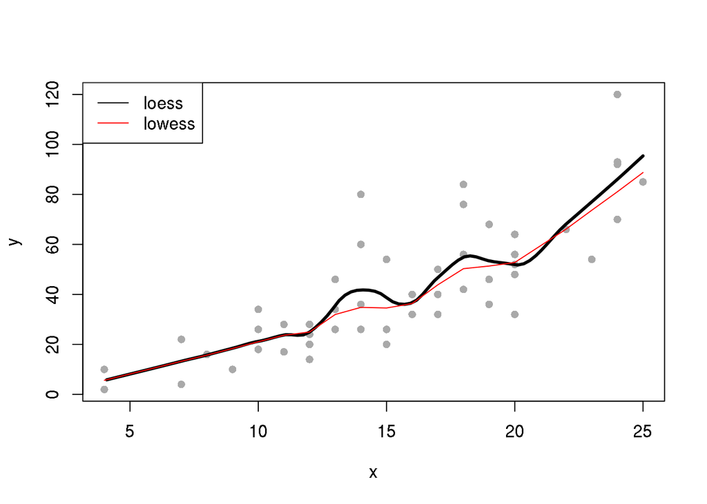

```r
fit <- loess(y~x, degree=1, span=1/3)
newx <- seq(min(y), max(x), len=100)
smooth <- predict(fit, newdata=data.frame(x=newx))
plot(x, y, col="darkgrey", pch=16)
lines(newx, smooth, col="black", lwd=3)
lines(lowess(y~x, f=1/3), col="red")
legend("topleft", legend=c("loess", "lowess"), col=c("black", "red"), lty=1)
```

```r
#car::qqPlot(residuals(loess(y~x)))
```

## Predicting with Linear Regression

```r
dataIdx <- (1:nrow(cars) %% 2 == 0) #mod
testIdx <- (1:nrow(cars) %% 2 == 1)
sum((dataIdx - testIdx)) #0
```

```
## [1] 0
```

```r
Y <- cars[dataIdx,]$dist
X <- cars[dataIdx,]$speed
#cross validation
test.Y <- cars[testIdx,]$dist
test.X <- cars[testIdx,]$speed
c(length(X), length(test.X))
```

```
## [1] 25 25
```

```r
c(mean(Y), mean(test.Y))
```

```
## [1] 42.52 43.44
```

```r
c(sd(Y), sd(test.Y))
```

```
## [1] 24.04530 27.87783
```

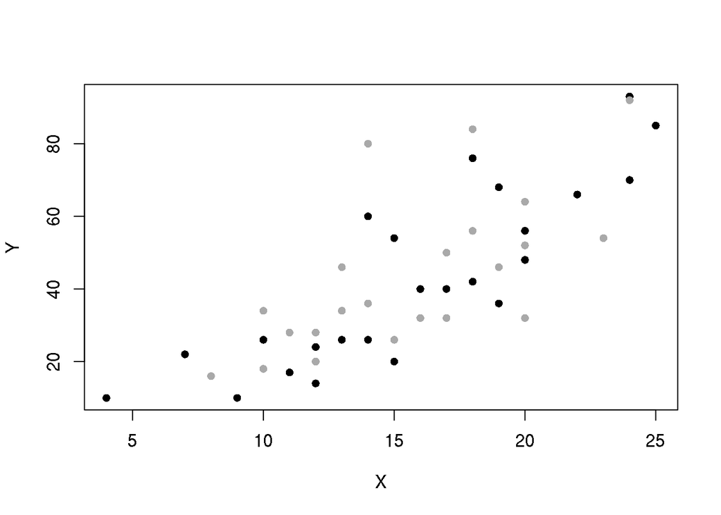

```r
plot(X, Y, col="black", pch=16)
points(test.X, test.Y, col="darkgray", pch=16)
```

```r
fit <- lm(Y ~ X)
yhat <- round(predict(fit))
test.yhat <- round(predict(fit, newdata=data.frame(X=test.X)))
# 1 - E(Y∣X=x) (conditional probability)
#error:
1 - mean(abs(Y - yhat) < 5)
```

```
## [1] 0.8
```

```r
1 - mean(abs(test.Y - test.yhat) < 5)
```

```
## [1] 0.68
```

```r
1 - mean(abs(test.Y - yhat) < 5)
```

```
## [1] 0.64
```

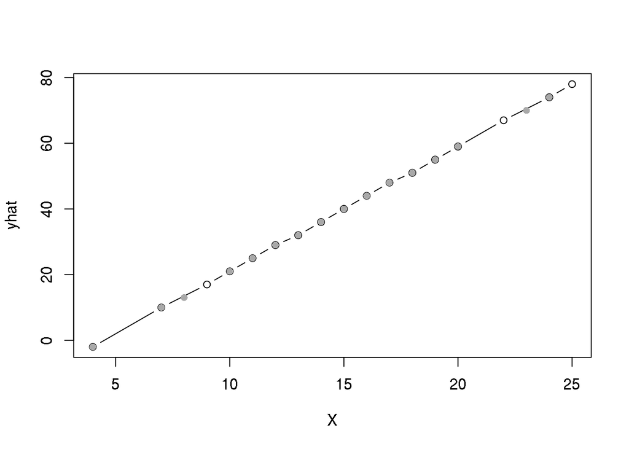

```r
plot(X, yhat, type="b")
points(test.X, test.yhat, pch=16, col="darkgrey")
```

## Predicting with K-nearest Neighbor (KNN)

```r
library(class)
k=3
yhat <- as.numeric(knn(data.frame(X), data.frame(X), Y, k=k))
test.yhat <- as.numeric(knn(data.frame(X), data.frame(test.X), Y, k=k))
#error
1 - mean(abs(Y - yhat) < 5)
```

```
## [1] 0.96
```

```r
1 - mean(abs(test.Y - test.yhat) < 5)
```

```
## [1] 0.92
```

```r
1 - mean(abs(test.Y - yhat) < 5)
```

```
## [1] 0.92
```

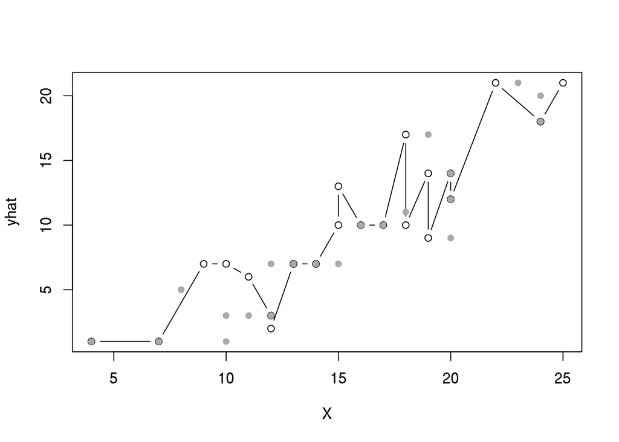

```r
plot(X, yhat, type="b")
points(test.X, test.yhat, pch=16, col="darkgrey")
```

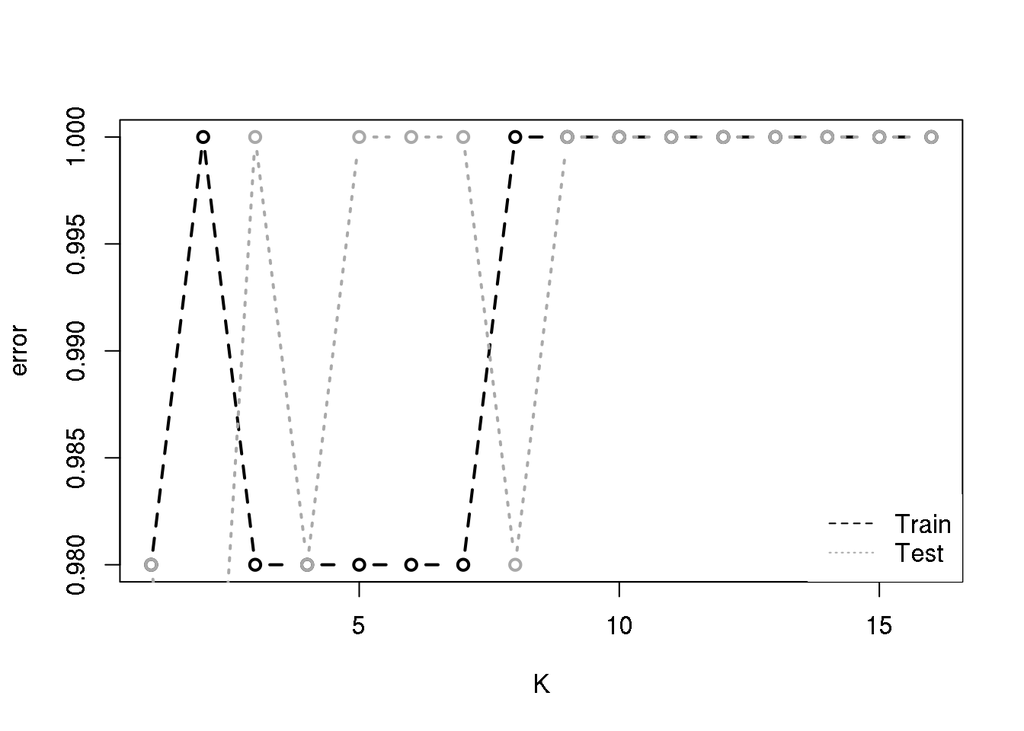

```r
train.error <- rep(0, 16)
test.error <- rep(0, 16)
idx <- seq(along=train.error)
for(k in idx){
  yhat <- knn(data.frame(X), data.frame(X), Y, k=k)
  train.error[k] <- 1 - mean((as.numeric(yhat) - 1) == y)

  yhat <- knn(data.frame(X), data.frame(test.X), Y, k = k)
  test.error[k] <- 1 - mean((as.numeric(yhat) - 1) == y)
}
plot(idx, train.error, type="n", xlab="K", ylab="error")
lines(idx, train.error,type="b", col="black", lty=2, lwd=2)
lines(idx, test.error,type="b", col="darkgray", lty=3, lwd=2)
legend("bottomright", c("Train","Test"), col=c("black","darkgray"), lty=c(2,3), box.lwd=0)
```

## Maximum-Likelihood Estimation (MLE)

MLE is a generalized form of least-squares estimation (LSE).

http://cran.r-project.org/doc/contrib/Ricci-distributions-en.pdf

```r
library(stats4)
```

Mean and standard deviation

```r
z <- (cars$speed - mean(cars$speed)) / sd(cars$speed) # standartize speed
c(mean(z), sd(z))
```

```
## [1] -5.42795e-17  1.00000e+00
```

```r
# estimate mu, sigma using log-likelihood function (L)
LL <- function(mu, sigma) {
  R <- dnorm(z, mu, sigma)
  -sum(log(R))
}
(fit <- mle(LL, start = list(mu = 0, sigma=1)))
```

```
##
## Call:
## mle(minuslogl = LL, start = list(mu = 0, sigma = 1))
##
## Coefficients:
##        mu     sigma
## 0.0000000 0.9899506
```

```r
#difference
coef(fit) - c(mean(z), sd(z))
```

```
##            mu         sigma
##  5.427950e-17 -1.004939e-02
```

```r
# speed (no standartization)
c(mean(cars$speed), sd(cars$speed))
```

```
## [1] 15.400000  5.287644
```

```r
LL <- function(mu, sigma) {
  R <- dnorm(cars$speed, mu, sigma)
  -sum(log(R))
}
(fit <- mle(LL, start = list(mu = 14, sigma=3),
            method = "L-BFGS-B", lower = c(-Inf, 0),
            upper = c(Inf, Inf)))
```

```
##
## Call:
## mle(minuslogl = LL, start = list(mu = 14, sigma = 3), method = "L-BFGS-B",
##     lower = c(-Inf, 0), upper = c(Inf, Inf))
##
## Coefficients:
##        mu     sigma
## 15.400005  5.234501
```

```r
#difference
coef(fit) - c(mean(cars$speed), sd(cars$speed))
```

```
##            mu         sigma
##  4.669697e-06 -5.314361e-02
```

Linear models

```r
#install.packages("bbmle")
library(bbmle)
fit <- lm(dist ~ speed, data=cars)
summary(fit)$coef
```

```
##               Estimate Std. Error   t value     Pr(>|t|)
## (Intercept) -17.579095  6.7584402 -2.601058 1.231882e-02
## speed         3.932409  0.4155128  9.463990 1.489836e-12
```

```r
residuals <- cars$dist - fit$fitted.values
c(mean(residuals), sd(residuals))
```

```
## [1] -3.592612e-17  1.522184e+01
```

```r
LL <- function(beta0, beta1, mu, sigma) {
  R <- cars$dist - cars$speed * beta1 - beta0
  R <- suppressWarnings(dnorm(R, mu, sigma))
  -sum(log(R))
}

fit <- mle2(LL, start=list(beta0=-15, beta1=3, mu=0, sigma=5))
coef(fit)
```

```
##      beta0      beta1         mu      sigma
## -16.282300   3.931623  -1.282300  15.068145
```

```r
residuals <- cars$dist - cars$speed * coef(fit)["beta1"] - coef(fit)["beta0"]
c(mean(residuals), sd(residuals))
```

```
## [1] -1.284697 15.221844
```